# Più liberi o più felici?

Esplorando il legame tra Felicità e Libertà nel contesto globale

## Overview

Questo studio si propone di fornire una panoramica della percezione media mondiale del senso di felicità e del senso di libertà nel periodo compreso tra il 2015 e il 2019, cercando di rispondere alle seguenti domande:

- **Qual è la distribuzione di Felicità e Libertà e cosa le caratterizza?**
- **Qual è il legame tra Felicità e Libertà?**
- **Qual è la percezione Mondiale di Felicità e Libertà?**

## Data Sources

Per l'analisi sono stati presi in considerazione i seguenti dataset con riferimento agli anni 2015-2019:

- [Human Freedom](https://www.kaggle.com/datasets/gsutters/the-human-freedom-index)

che offre una panoramica mondiale di come le nazioni percepiscono il senso di libertà

- [World Happiness Report](https://www.kaggle.com/datasets/unsdsn/world-happiness)

Che offre una panoramica mondiale di come le nazioni percepiscono il senso di felicità

## Struttura dei dataset

Entrambi i dataset hanno la seguente struttura delle colonne: **Primary key (country-year):** ogni riga in entrambi i dataset è caratterizzata dalla chiave nazione-anno **Total Score:** ogni dataset ha una colonna *score*, che indica il punteggio di felicità o libertà stimato in una scala [0-10] **Variabili secondarie:** una serie di variabili(sotto-aree) che influenzano il total score rispetto al proprio dataset di appartenenza

## Glossario

Con riferimento al dataset della Libertà, di seguito vengono riportati gli acronimi che verranno usati più frequentemente:

- **pf_score_**: *Personal Freedom*, è una media tra le variabili che hanno impatto sulla libertà personale
- **ef_score_**: *Economic Freedom*, è una media tra le variabili che hanno impatto sulla libertà economica
- **hf_score**: *Human Freedom*, è una media tra pf_score e ef_score

```python
#panoramica delle variabili che influenzano libertà personale ed economica
plot_tree(data)
```

```
  - hf_score
    - pf_score
      - pf_rol: rule&role
      - pf_ss: security&safety
      - pf_movement: movement
      - pf_religion: religion
      - pf_expression: expression and information
      - pf_identity: identity and relationship
      - pf_association: association, assembly and civil society
    - ef_score
      - ef_government: government
      - ef_gender: gender
      - ef_legal: legal system and property right
      - ef_money: access to sound money
      - ef_trade: freedom to trade internationally
      - ef_regulation: regulation of credit and business
```

# Qual è la distribuzione di Felicità e Libertà e cosa le caratterizza?

Cosa sono? Di cosa sono fatte?

A supporto di questa analisi, verranno mostrati i seguenti grafici: </p>

- **Boxplot:** che metterà in luce la distribuzione dei livelli di felicità e libertà
- **Pieplot:** che identificherà le caratteristiche che distinguono felicità e libertà

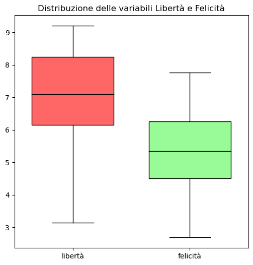

```python
show_boxplot()
```

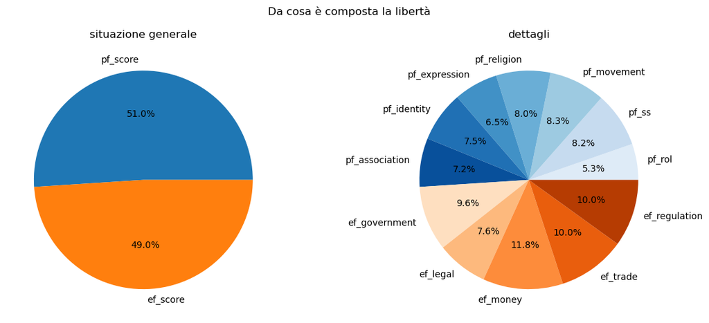

```python
freedom_pie_plot()
```

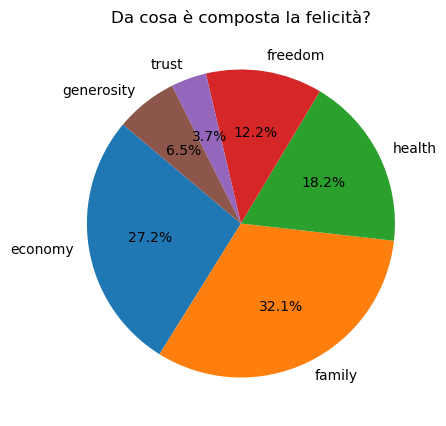

```python
happiness_pie_plot()
```

## Qual è il legame tra Felicità e Libertà?

Cercheremo di capire se esiste una relazione significativa tra felicità e libertà e in che modo si influenzano reciprocamente.

A supporto dell'analisi verranno generati i seguenti grafici:</p>

- **Grafico a dispersione:** che permetterà di valutare l'effettiva relazione tra felicità e libertà
- **Heatmap:** che permetterà di valutare la relazione tra i componenti di felicità e libertà

```
Con retta di regressione: freedom = 0.7 * happiness + 3.26
```

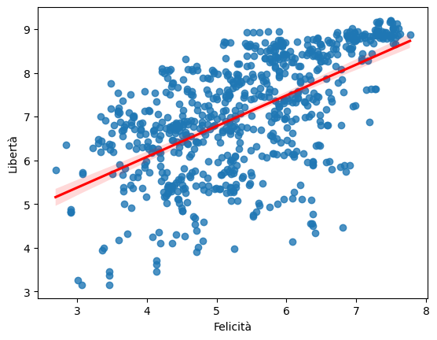

```python
print('Con retta di regressione: freedom =', round(m, 2), '* happiness +', round(b, 2) )
scatter_plot()
```

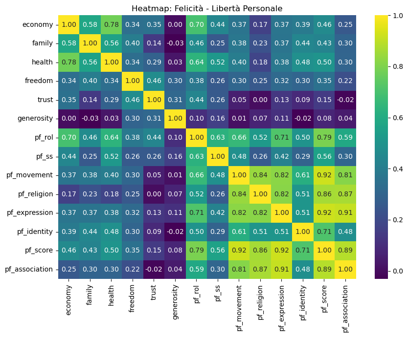

```python
heatmap_happy_pfreedom_plot()
```

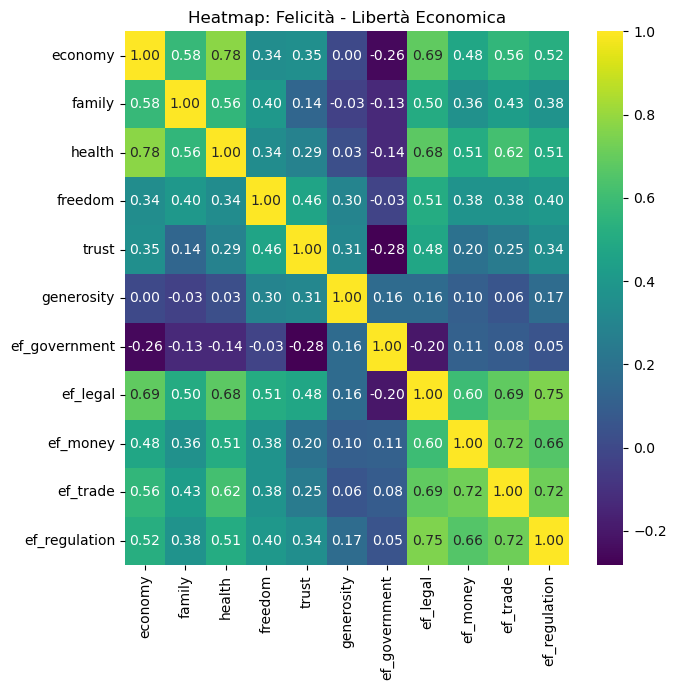

```python
heatmap_happy_efreedom_plot()
```

## Qual è la percezione Mondiale di Felicità e Libertà?

Esamineremo la percezione mondiale di felicità e libertà nel periodo preso in considerazione. A supporto di questa analisi verranno generati i seguenti grafici:

- **Geomap:** che darà una panoramica della percezione di felicità e libertà nei vari continenti
- **Grafico a barre:**

che evidenzierà le maggiori percezioni per continenti e macro regioni mondiali

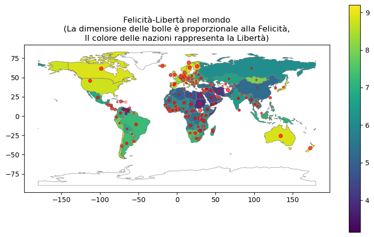

```python
# Create a chart with geopandas
geopandas_plot()
```

```python
print('Continenti per media punteggi felicità e libertà')
happy_free_by_continents.sort_values('hf_score', ascending=False).rename(columns={'continent': 'continente','happiness_score': 'felicità', 'hf_score': 'libertà'})
```

```
Continenti per media punteggi felicità e libertà
```

|  | continente | felicità | libertà |
| --- | --- | --- | --- |
| 4 | Oceania | 7.294600 | 9.035000 |
| 2 | Europe | 6.149688 | 8.253228 |
| 3 | North America | 6.099500 | 7.664853 |
| 5 | South America | 6.126635 | 7.210192 |
| 1 | Asia | 5.261165 | 6.450825 |
| 0 | Africa | 4.259495 | 6.150545 |

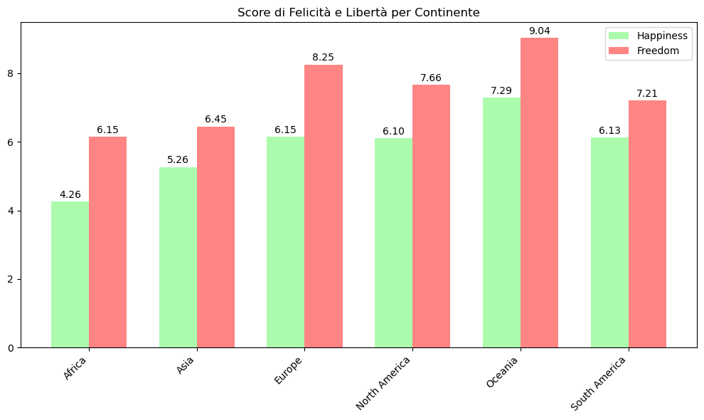

```python
continent_bar_plot()
```

```python
print('Regioni per media punteggi felicità e libertà')
happy_free_by_region.sort_values('hf_score', ascending=False).rename(columns={'region': 'regione','happiness_score': 'felicità', 'hf_score': 'libertà'})
```

```
Regioni per media punteggi felicità e libertà
```

|  | regione | felicità | libertà |
| --- | --- | --- | --- |
| 6 | Oceania | 7.294600 | 9.035000 |
| 5 | North America | 7.174700 | 8.860000 |
| 9 | Western Europe | 6.962788 | 8.764353 |
| 2 | Eastern Europe | 5.508307 | 7.892018 |
| 1 | East Asia | 5.691320 | 7.802400 |
| 3 | Latin America & the Caribbean | 6.014582 | 7.341273 |
| 0 | Caucasus & Central Asia | 5.011800 | 6.779000 |
| 7 | South Asia | 4.997029 | 6.321304 |
| 8 | Sub-Saharan Africa | 4.139638 | 6.278023 |
| 4 | Middle East & North Africa | 5.334624 | 5.450118 |

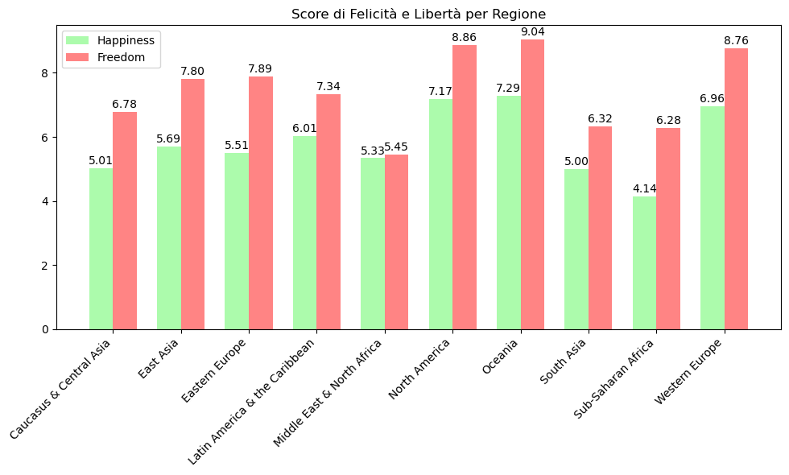

```python
region_bar_plot()
```

## Trend Felicità e Libertà

Sono infine stati estratti una serie di dati inerenti l'evoluzione della felicità e della libertà tra gli anni 2015-2019, al fine di capirne l'andamento.

Per fare questo sono stati presi in considerazione i seguenti subset</p>

- Trend generale
- Trend delle nazioni più felici
- Trend delle nazioni più libere

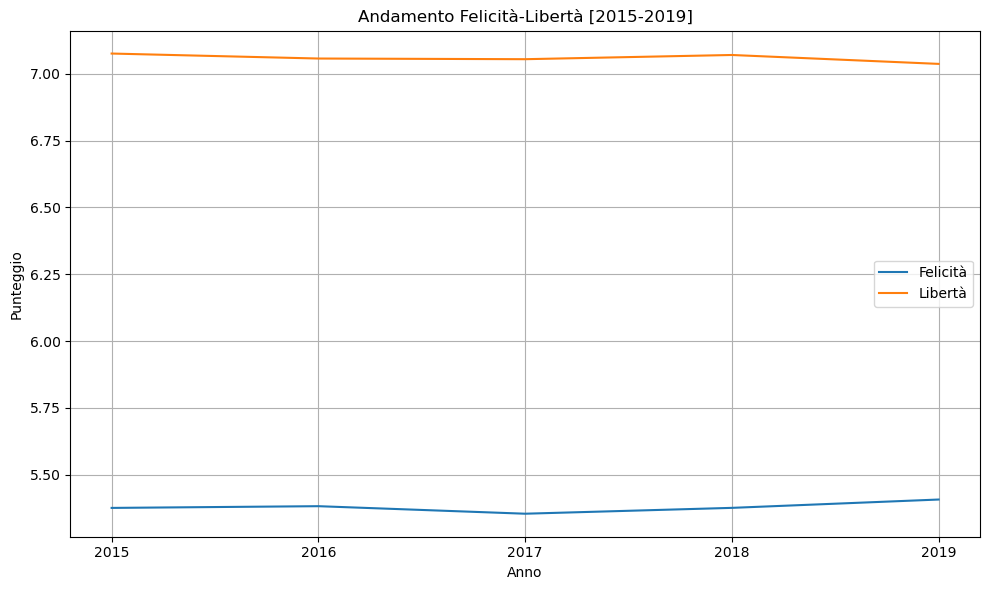

```python
#Andamento felicità - libertà (libertà economica- libertà personale) mondiale [2015-2019]
trend_happy_free()
```

[figure not shown]

```python
more_happy_trend()
```

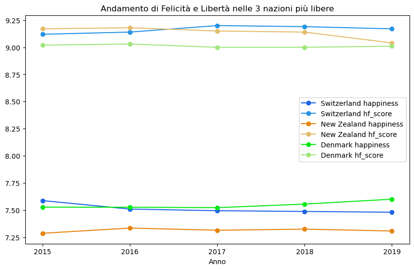

```python
more_free_trend()
```

## In Conclusione

- Ci percepiamo più liberi (mediana = 7.12) che non felici (mediana = 5.32)
- E' stato visto che felicità e libertà sono legate da una relazione: y = 0.71x + 3.26
- E' stato messo in evidenza quanto ci sia più correlazione tra *felicità e libertà economica*, piuttosto che tra *felicità e libertà personale*
- E' stata data una panoramica della percezione che le nazioni del mondo hanno rispetto a felicità e libertà
- E' stata data una breve panoramica sul trend della percezione di felicità e libertà negli anni [2015-2019]